# Portfoliomanagement and Financial Analysis - Assignment 6

Submit until Monday 2020-11-02, 13:00

Sozzi, Maurizio

```r
#remotes::install_github("braverock/FactorAnalytics",  build_vignettes = TRUE, force = TRUE)
pacman::p_load(tidyverse,tidyquant,FFdownload,FactorAnalytics,PerformanceAnalytics)
```

**Please** remember to put your assignment solutions in `rmd` format using **many** chunks and putting readable text in between, similar to my examples given in Research Methods and Assignment 1!

For all exercises: Please use the Assignment-Forum to post your questions, I will try my best to help you along! If you follow the vignettes from `factorAnalytics`, wherever it says `z.score=T`, please exchange it for either `z.score='crossSection'` or `z.score='timeSeries'` depending on the task at hand.

## Exercise 1: Estimating the CAPM (from A05)

In this exercise we want to estimate the CAPM. Please read carefully through the two documents provided (right hand side: files). Then we start to collect the necessary data:

1. From Datastream get the last 10 years of data from the 100 stocks of the S&P100 using the list `LS&P100I` (S&P 100): total return index (RI) and market cap (MV)
2. Further import the Fama-French-Factors from Kenneth Frenchs homepage (monthly, e.g. using `FFdownload`). From both datasets we select data for the last (available) 60 months, calculate returns (simple percentage) for the US-Stocks and eliminate those stocks that have NAs for this period.
3. Now subtract the risk-free rate from all the stocks. Then estimate each stocks beta with the market: Regress all stock excess returns on the market excess return and save all betas (optimally use `mutate` and `map` in combination with `lm`). Estimate the mean-return for each stock and plot the return/beta-combinations. Create the security market line and include it in the plot! What do you find?
4. In a next step (following both documents), we sort the stocks according to their beta and build ten value-weighted portfolios (with more or less the same number of stocks). Repeat a) for the ten portfolios. What do you observe?
5. In the third step you follow page 6-8 of the second document and estimate the second-pass regression with the market and then market & idiosyncratic risk. What do you observe? Present all your results in a similar fashion as in the document.

## Exercise 2: Calculating and checking the CAPM cont. (from A05)

```r
pacman::p_load(tidyverse,tidyquant,FFdownload,PortfolioAnalytics,nloptr,readxl,quantmod,FFdownload,timetk, dplyr, xts)
```

As we have seen: the CAPM for small portfolios does not work very well, and so we start using portfolios that get rid of the idiosyncratic risk! Go to Kenneth French’s Homepage again and download the following datasets: “Portfolios Formed on Market Beta” (where we will use 10 monthly value weighted portfolios formed on beta) and “25 Portfolios Formed on Size and Market Beta” (same thing) as well as the market factor and rf (as before). Now we are going to check the CAPM like famous researchers have done it! We can use returns as they are in the files (simple returns)!

```r
inputlist<-c("F-F_Research_Data_Faktors_CSV.zip","Portfolios_Formed_on_BETA_CSV.zip")

#Now process only these files if they can be matched (download only)
FFdownload(output_file = "FFdata.RData", inputlist = inputlist, exclude_daily=TRUE)

load("FFdata.RData")
portf_mkt_betatest<-(FFdownload$x_Portfolios_Formed_on_BETA$monthly$value_weighted_returns)

portf_mkt_betatest
```

```r
#Download the Portfolios from Kenneth French's Homepage
portf_mkt_beta <- "https://mba.tuck.dartmouth.edu/pages/faculty/ken.french/ftp/Portfolios_Formed_on_BETA_CSV.zip"
 portf_mkt_beta_csv <- "Portfolios_Formed_on_BETA.csv"
 temp <- tempfile()
download.file(portf_mkt_beta, temp, quiet = TRUE)
portf_mkt_beta <- read_csv(unz(temp, portf_mkt_beta_csv), skip = 15, quote = "\",") %>%
  dplyr::rename(date = "X1") %>%
  mutate_at(vars(-date), as.numeric) %>%
  mutate(date = rollback(ymd(parse_date_time(date, "%Y%m") + months(1))))%>%
  filter(date >= first('1964-01-01') & date <= '2019-12-31')

#Download the market factor and rf (Fama/French 3 Research Factors)
mkt_factors <- "https://mba.tuck.dartmouth.edu/pages/faculty/ken.french/ftp/F-F_Research_Data_Factors_CSV.zip"
 mkt_factors_csv <- "F-F_Research_Data_Factors.CSV"
 temp <- tempfile()
download.file(mkt_factors, temp, quiet = TRUE)
mkt_factors <- read_csv(unz(temp, mkt_factors_csv), skip = 3, quote = "\",") %>%
  dplyr::rename(date = X1) %>%
  mutate_at(vars(-date), as.numeric) %>%
  mutate(date = rollback(ymd(parse_date_time(date, "%Y%m") + months(1)))) %>%
  filter(date >= first('1964-01-01') & date <= '2019-12-31')
```

1. Subtract the risk-free rate from the first set of 10 portfolios (only sorted on beta) (Lo 10,., Hi 10) and estimate each stocks beta with the market. Estimate the mean-return for each stock and plot the return/beta-combinations. Create the security market line and include it in the plot! What do you find? (You can split the file in 2-3 different time blocks and see if something changes). * Now we are done with the first-pass regression.*

Subtract the risk-free rate from the first set of 10 portfolios (only sorted on beta) (Lo 10,., Hi 10) and estimate each stocks beta with the market.

```r
#join data
ten_portf <- portf_mkt_beta[1:672, -c(2:6)]
ten_portf_joined <- left_join(mkt_factors, ten_portf)

mkt_factors
ten_portf
ten_portf_joined
```

| date | Mkt-RF | SMB | HML | RF | Lo10 | Dec2 | Dec3 | Dec4 | Dec5 | Dec6 | Dec7 | Dec8 | Dec9 | Hi10 |
| --- | --- | --- | --- | --- | --- | --- | --- | --- | --- | --- | --- | --- | --- | --- |
| 1964-01-31 | 2.24 | -0.19 | 1.59 | 0.30 | 3.74 | 1.41 | 2.74 | 2.76 | 1.76 | 2.95 | 2.88 | 4.35 | 2.07 | 0.96 |
| 1964-02-29 | 1.54 | 0.10 | 2.83 | 0.26 | 1.08 | 1.72 | 0.62 | 2.14 | 2.36 | 1.66 | 1.74 | 3.78 | 2.53 | 3.89 |
| 1964-03-31 | 1.41 | 0.99 | 3.32 | 0.31 | 1.05 | 0.76 | 0.05 | 1.20 | 2.92 | 1.69 | 2.28 | 3.90 | 5.89 | 6.12 |
| 1964-04-30 | 0.10 | -1.37 | -0.55 | 0.29 | 2.65 | 1.81 | 1.57 | 1.38 | -0.89 | 0.07 | -2.26 | -2.65 | -1.79 | -4.98 |
| 1964-05-31 | 1.42 | -0.90 | 1.98 | 0.26 | 1.64 | 1.71 | 0.23 | 2.81 | 2.08 | 0.84 | 0.71 | 3.09 | 1.41 | 1.33 |
| 1964-06-30 | 1.27 | -0.26 | 0.68 | 0.30 | 1.52 | 2.20 | 3.81 | 0.34 | 1.14 | 1.39 | 2.07 | 0.01 | 2.14 | 1.66 |
| 1964-07-31 | 1.74 | 0.28 | 0.68 | 0.30 | 4.07 | 0.67 | 4.86 | 2.24 | 3.43 | 1.02 | 1.07 | -0.54 | 1.22 | 0.48 |
| 1964-08-31 | -1.44 | 0.09 | 0.09 | 0.28 | 1.34 | -1.59 | 0.13 | -1.23 | -1.92 | -0.62 | -1.56 | -2.59 | -1.79 | -2.65 |
| 1964-09-30 | 2.69 | -0.51 | 1.65 | 0.28 | 2.88 | 1.17 | 3.48 | 3.19 | 3.58 | 3.72 | 3.08 | 2.91 | 5.75 | 5.68 |
| 1964-10-31 | 0.59 | 0.43 | 1.14 | 0.29 | 1.17 | 0.95 | 0.94 | 2.33 | 1.46 | 1.18 | 0.64 | -2.54 | -0.42 | 1.97 |

[output cut: 662 more lines]

```r
#substract Risk-Free-Rate
ten_portf_rf <- mutate(ten_portf_joined, Lo10rf = Lo10 - RF, Dec2rf = Dec2 - RF, Dec3rf = Dec3 - RF, Dec4rf = Dec4 - RF, Dec5rf = Dec5 -RF, Dec6rf = Dec6 - RF, Dec7rf = Dec7 - RF, Dec8rf = Dec8 - RF, De9rf = Dec9 - RF, Hi10rf = Hi10 - RF)
ten_portf_rf <- ten_portf_rf[-2:-15]

view(ten_portf_rf)
ten_portf_rf
```

| date | Lo10rf | Dec2rf | Dec3rf | Dec4rf | Dec5rf | Dec6rf | Dec7rf | Dec8rf | De9rf | Hi10rf |
| --- | --- | --- | --- | --- | --- | --- | --- | --- | --- | --- |
| 1964-01-31 | 3.44 | 1.11 | 2.44 | 2.46 | 1.46 | 2.65 | 2.58 | 4.05 | 1.77 | 0.66 |
| 1964-02-29 | 0.82 | 1.46 | 0.36 | 1.88 | 2.10 | 1.40 | 1.48 | 3.52 | 2.27 | 3.63 |
| 1964-03-31 | 0.74 | 0.45 | -0.26 | 0.89 | 2.61 | 1.38 | 1.97 | 3.59 | 5.58 | 5.81 |
| 1964-04-30 | 2.36 | 1.52 | 1.28 | 1.09 | -1.18 | -0.22 | -2.55 | -2.94 | -2.08 | -5.27 |
| 1964-05-31 | 1.38 | 1.45 | -0.03 | 2.55 | 1.82 | 0.58 | 0.45 | 2.83 | 1.15 | 1.07 |
| 1964-06-30 | 1.22 | 1.90 | 3.51 | 0.04 | 0.84 | 1.09 | 1.77 | -0.29 | 1.84 | 1.36 |
| 1964-07-31 | 3.77 | 0.37 | 4.56 | 1.94 | 3.13 | 0.72 | 0.77 | -0.84 | 0.92 | 0.18 |
| 1964-08-31 | 1.06 | -1.87 | -0.15 | -1.51 | -2.20 | -0.90 | -1.84 | -2.87 | -2.07 | -2.93 |
| 1964-09-30 | 2.60 | 0.89 | 3.20 | 2.91 | 3.30 | 3.44 | 2.80 | 2.63 | 5.47 | 5.40 |
| 1964-10-31 | 0.88 | 0.66 | 0.65 | 2.04 | 1.17 | 0.89 | 0.35 | -2.83 | -0.71 | 1.68 |

[output cut: 662 more lines]

[output not shown]

```r
?lm()
#Calculate Betas for each portfolio
betas_ten_portf_lm <- lm(ten_portf_xts ~ mkt_factors_xts[, 1])
betas_ten_portf_lm
```

```
Call:
lm(formula = ten_portf_xts ~ mkt_factors_xts[, 1])

Coefficients:
                      Lo 10   Dec 2   Dec 3   Dec 4   Dec 5   Dec 6   Dec 7   Dec 8   Dec 9
(Intercept)           0.6167  0.5193  0.5202  0.5410  0.3932  0.4383  0.2864  0.3698  0.2639
mkt_factors_xts[, 1]  0.6050  0.7301  0.8307  0.9661  1.0150  1.0791  1.1517  1.2745  1.3837
                      Hi 10
(Intercept)           0.1370
mkt_factors_xts[, 1]  1.6075
```

```r
betas_ten_portf <- CAPM.beta(Ra = ten_portf_xts, Rb = mkt_factors_xts[, 1], Rf = 0)
betas_ten_portf
```

```
                 Lo 10     Dec 2     Dec 3     Dec 4    Dec 5    Dec 6    Dec 7    Dec 8
Beta: Mkt-RF 0.6050351 0.7301365 0.8306731 0.9660836 1.015024 1.079079 1.151653 1.274483
                Dec 9    Hi 10
Beta: Mkt-RF 1.383712 1.607482
```

Estimate the mean-return for each stock and plot the return/beta-combinations.

```r
#Estimate Mean Return
mean_ten_portf_rf_xts <- as.data.frame(lapply(ten_portf_rf_xts, FUN=mean))
mean_ten_portf_rf_xts
```

| Lo10rf | Dec2rf | Dec3rf | Dec4rf | Dec5rf | Dec6rf | Dec7rf | Dec8rf | De9rf | Hi10rf |
| --- | --- | --- | --- | --- | --- | --- | --- | --- | --- |
| 0.5617708 | 0.5315327 | 0.5863393 | 0.6797024 | 0.5581696 | 0.6376339 | 0.5246131 | 0.6739286 | 0.6266369 | 0.6196875 |

```r
#Plot the return/beta-combinations
plot.default(x = betas_ten_portf, xlim=c(0, 2),
             y = mean_ten_portf_xts, ylim=c(0, 1),
             xlab = "Beta", ylab = "Mean Return",
             main = "Return/Beta-combinations")
```

[output not shown]

Create the security market line and include it in the plot! What do you find?

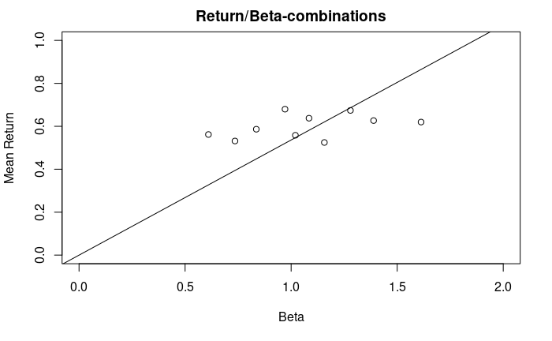

```r
mean_mkt <- as.data.frame(lapply(mkt_factors_xts[, 1], FUN=mean))
y_mkt <- mean_mkt[1, 1]
plot.default(x = betas_ten_portf, xlim=c(0, 2),
             y = mean_ten_portf_rf_xts, ylim=c(0, 1),
             xlab = "Beta", ylab = "Mean Return",
             main = "Return/Beta-combinations",
             abline(0, y_mkt))
```

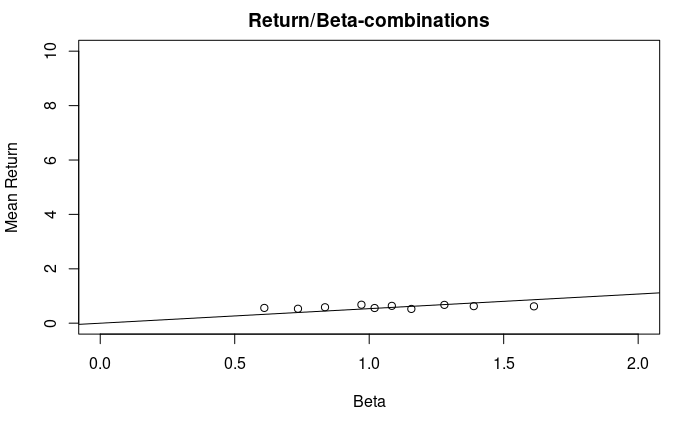

```r
plot.default(x = betas_ten_portf, xlim=c(0, 2),
             y = mean_ten_portf_rf_xts, ylim=c(0, 10),
             xlab = "Beta", ylab = "Mean Return",
             main = "Return/Beta-combinations",
             abline(0, y_mkt))
```

```r
#summary
summary_CAPM_ten_portf <- (table.CAPM(Ra = ten_portf_rf_xts, Rb = mkt_factors_xts[, 1], Rf = 0)[1:9, ])
```

(You can split the file in 2-3 different time blocks and see if something changes). * Now we are done with the first-pass regression.*

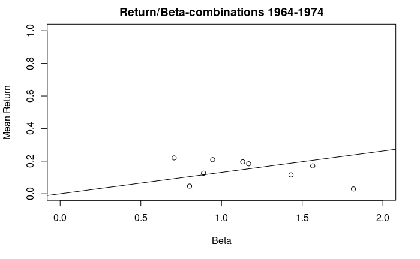

```r
#look for first 10 years
ten_portf_rf_10yrs_xts <- ten_portf_rf[1:120, ] %>%
  tk_xts(date_var = date, silent = TRUE)
betas_ten_portf_rf_10yrs <- CAPM.beta(Ra = ten_portf_rf_10yrs_xts, Rb = mkt_factors_xts[1:120, 1], Rf = 0)
mean_ten_portf_rf_10yrs_xts <- as.data.frame(lapply(ten_portf_rf_10yrs_xts, FUN=mean))
mean_mkt_10yrs <- as.data.frame(lapply(mkt_factors_xts[1:120, 1], FUN=mean))
y_mkt_10yrs <- mean_mkt_10yrs[1, 1]
plot.default(x = betas_ten_portf_rf_10yrs, xlim=c(0, 2),
             y = mean_ten_portf_rf_10yrs_xts, ylim=c(0, 1),
             xlab = "Beta", ylab = "Mean Return",
             main = "Return/Beta-combinations 1964-1974",
             abline(0, y_mkt_10yrs))
```

```r
summary_CAPM_ten_portf_10yrs <- (table.CAPM(Ra = ten_portf_rf_xts[1:120, ], Rb = mkt_factors_xts[1:120, 1], Rf = 0)[1:9, ])
summary_CAPM_ten_portf_10yrs
```

|  | Lo10rf to Mkt-RF | Dec2rf to Mkt-RF | Dec3rf to Mkt-RF | Dec4rf to Mkt-RF | Dec5rf to Mkt-RF | Dec6rf to Mkt-RF | Dec7rf to Mkt-RF | Dec8rf to Mkt-RF | De9rf to Mkt-RF | Hi10rf to Mkt-RF |
| --- | --- | --- | --- | --- | --- | --- | --- | --- | --- | --- |
| Alpha | 0.1272 | -0.0582 | 0.0095 | 0.0851 | 0.0475 | 0.0305 | -0.2370 | -0.0718 | -0.0342 | -0.2087 |
| Beta | 0.7065 | 0.8023 | 0.8886 | 0.9455 | 1.1314 | 1.1685 | 1.2601 | 1.4307 | 1.5652 | 1.8175 |
| Beta+ | 0.6189 | 0.7279 | 0.9062 | 1.0647 | 1.1989 | 1.1778 | 1.3302 | 1.4950 | 1.4848 | 1.7092 |
| Beta- | 0.8591 | 0.8510 | 0.8854 | 0.7909 | 1.1856 | 1.1260 | 1.1400 | 1.3138 | 1.5166 | 1.8216 |
| R-squared | 0.7237 | 0.8643 | 0.8675 | 0.8762 | 0.9066 | 0.8836 | 0.9002 | 0.8756 | 0.8576 | 0.7741 |
| Annualized Alpha | 3.2073 | -0.5129 | 0.1202 | 1.6658 | 0.7443 | 0.4343 | -0.9611 | -0.5908 | -0.3414 | -0.9397 |
| Correlation | 0.8507 | 0.9297 | 0.9314 | 0.9360 | 0.9521 | 0.9400 | 0.9488 | 0.9357 | 0.9261 | 0.8798 |
| Correlation p-value | 0.0000 | 0.0000 | 0.0000 | 0.0000 | 0.0000 | 0.0000 | 0.0000 | 0.0000 | 0.0000 | 0.0000 |
| Tracking Error | 7.1281 | 5.0726 | 4.9418 | 4.8729 | 5.2347 | 6.1848 | 6.6890 | 9.3535 | 11.5483 | 17.3136 |

[figure not shown]

|  | Lo10rf to Mkt-RF | Dec2rf to Mkt-RF | Dec3rf to Mkt-RF | Dec4rf to Mkt-RF | Dec5rf to Mkt-RF | Dec6rf to Mkt-RF | Dec7rf to Mkt-RF | Dec8rf to Mkt-RF | De9rf to Mkt-RF | Hi10rf to Mkt-RF |
| --- | --- | --- | --- | --- | --- | --- | --- | --- | --- | --- |
| Alpha | 0.3627 | 0.2741 | 0.3290 | 0.2914 | 0.0910 | 0.1504 | -0.0613 | 0.0495 | -0.3346 | -0.3788 |
| Beta | 0.5151 | 0.5932 | 0.7432 | 0.9229 | 0.9609 | 1.0464 | 1.1901 | 1.2941 | 1.4573 | 1.7308 |
| Beta+ | 0.5248 | 0.6635 | 0.7943 | 1.0016 | 1.0528 | 1.1095 | 1.2529 | 1.3217 | 1.5273 | 1.8484 |
| Beta- | 0.4971 | 0.6044 | 0.6944 | 0.8968 | 0.9144 | 1.0589 | 1.2573 | 1.2078 | 1.3151 | 1.5217 |
| R-squared | 0.5003 | 0.5693 | 0.7389 | 0.8224 | 0.8417 | 0.8439 | 0.8748 | 0.8747 | 0.8446 | 0.8309 |
| Annualized Alpha | 40.0038 | 17.2980 | 29.3549 | 20.5108 | 1.8435 | 4.3702 | -0.5318 | 0.7852 | -0.9925 | -0.9967 |
| Correlation | 0.7073 | 0.7545 | 0.8596 | 0.9069 | 0.9174 | 0.9187 | 0.9353 | 0.9353 | 0.9190 | 0.9116 |
| Correlation p-value | 0.0000 | 0.0000 | 0.0000 | 0.0000 | 0.0000 | 0.0000 | 0.0000 | 0.0000 | 0.0000 | 0.0000 |
| Tracking Error | 10.6434 | 9.8881 | 7.6906 | 6.5580 | 6.2995 | 6.8083 | 7.3552 | 8.5982 | 11.6559 | 16.0942 |

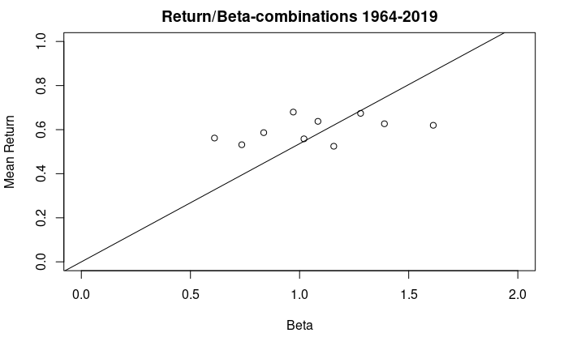

|  | Lo10rf to Mkt-RF | Dec2rf to Mkt-RF | Dec3rf to Mkt-RF | Dec4rf to Mkt-RF | Dec5rf to Mkt-RF | Dec6rf to Mkt-RF | Dec7rf to Mkt-RF | Dec8rf to Mkt-RF | De9rf to Mkt-RF | Hi10rf to Mkt-RF |
| --- | --- | --- | --- | --- | --- | --- | --- | --- | --- | --- |
| Alpha | 0.2346 | 0.1372 | 0.1381 | 0.1589 | 0.0111 | 0.0562 | -0.0957 | -0.0123 | -0.1182 | -0.2451 |
| Beta | 0.6101 | 0.7352 | 0.8357 | 0.9711 | 1.0201 | 1.0841 | 1.1567 | 1.2795 | 1.3888 | 1.6125 |
| Beta+ | 0.6029 | 0.8027 | 0.8648 | 1.0652 | 1.0685 | 1.1251 | 1.1118 | 1.2537 | 1.3354 | 1.5921 |
| Beta- | 0.6494 | 0.7399 | 0.8252 | 0.8997 | 0.9885 | 1.0683 | 1.1558 | 1.2140 | 1.3421 | 1.5284 |
| R-squared | 0.6187 | 0.7359 | 0.8301 | 0.8817 | 0.8976 | 0.8932 | 0.8920 | 0.8815 | 0.8511 | 0.8147 |
| Annualized Alpha | 11.5377 | 3.6801 | 3.7241 | 4.8673 | 0.1416 | 0.9275 | -0.7011 | -0.1380 | -0.7789 | -0.9658 |
| Correlation | 0.7866 | 0.8579 | 0.9111 | 0.9390 | 0.9474 | 0.9451 | 0.9444 | 0.9389 | 0.9226 | 0.9026 |
| Correlation p-value | 0.0000 | 0.0000 | 0.0000 | 0.0000 | 0.0000 | 0.0000 | 0.0000 | 0.0000 | 0.0000 | 0.0000 |
| Tracking Error | 9.4135 | 7.8325 | 6.2840 | 5.4407 | 5.2607 | 5.8559 | 6.5844 | 8.3229 | 10.6522 | 14.9858 |

2. In the second-pass regression we now regress the average stock returns on the betas estimated before. What do you find in the coefficients and does this contradict the CAPM? Try different time periods again and see what you find. (all of the interpretations are in BKM pp.416f).

```r
betas_ten_portf
```

```
                 Lo 10     Dec 2     Dec 3     Dec 4    Dec 5    Dec 6    Dec 7    Dec 8    Dec 9    Hi 10
Beta: Mkt-RF 0.6050351 0.7301365 0.8306731 0.9660836 1.015024 1.079079 1.151653 1.274483 1.383712 1.607482
```

```r
mean_ten_portf_rf_xts
```

| Lo10rf | Dec2rf | Dec3rf | Dec4rf | Dec5rf | Dec6rf | Dec7rf | Dec8rf | De9rf | Hi10rf |
| --- | --- | --- | --- | --- | --- | --- | --- | --- | --- |
| 0.5617708 | 0.5315327 | 0.5863393 | 0.6797024 | 0.5581696 | 0.6376339 | 0.5246131 | 0.6739286 | 0.6266369 | 0.6196875 |

```r
CAPM_Theroy<-betas_ten_portf/mean_ten_portf_rf_xts

CAPM_Theroy
```

| Lo10rf | Dec2rf | Dec3rf | Dec4rf | Dec5rf | Dec6rf | Dec7rf | Dec8rf | De9rf | Hi10rf |
| --- | --- | --- | --- | --- | --- | --- | --- | --- | --- |
| 1.077014 | 1.373644 | 1.416711 | 1.421333 | 1.818486 | 1.692318 | 2.195243 | 1.891124 | 2.208156 | 2.594021 |

```r
#There are a number of reasons we expect might the CAPM to fail:
#1. Imperfect measures of the market portfolio
#2. Beta is an incomplete measure of risk
#3. Tax effects
#4. Non - normality of returns
#5. No riskless asset
#6. Divergent borrowing and lending rates
```

3. Now do the extended second pass regression (regress on betas and residual-sds that you can extract from the regression) and see what you find for different periods. Interpret according to concept check 13.2. One of the (many) problems of the CAPM can be the correlation between residual variances and betas. Calculate and interpret.

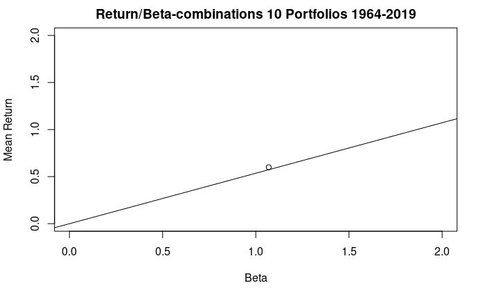

```r
#Look at a) -> We now do it with the mean return of every portfolio combined...

#1964-2019
com_mean_ten_portf_rf <- sum(mean_ten_portf_rf_xts)/10
mean_betas_ten_portf <- sum(betas_ten_portf)/10
plot.default(x = mean_betas_ten_portf, xlim=c(0, 2),
             y = com_mean_ten_portf_rf, ylim=c(0, 2),
             xlab = "Beta", ylab = "Mean Return",
             main = "Return/Beta-combinations 10 Portfolios 1964-2019",
             abline(0, y_mkt))
```

```r
NA
NA
```

[figure not shown]

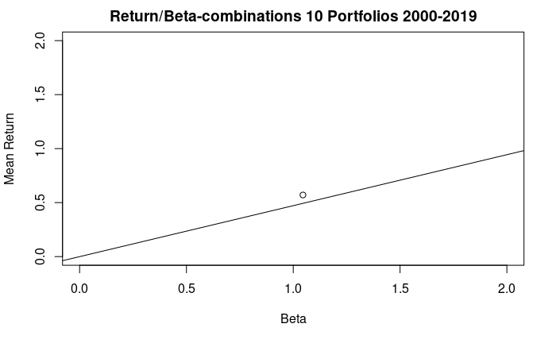

[output not shown]

4. Try again with 25 portfolios sorted on size and beta. What do you find? Is that interesting?

```r
inputlist1<-c("F-F_Research_Data_Faktors_CSV.zip","25_Portfolios_Formed_on_Size_and Market_Beta_CSV.zip")

#Now process only these files if they can be matched (download only)
FFdownload(output_file = "FFdata.RData", inputlist = inputlist1, exclude_daily=TRUE)
```

```
Step 1: getting list of all the csv-zip-files!

Step 2: Downloading 2 zip-files

Step 3: Start processing 2 csv-files
```

```r
load("FFdata.RData")
twentyfive_portf<-(FFdownload$x_25_Portfolios_Formed_on_Size_and Market_Beta$monthly$value_weighted_returns)
```

[output not shown]

```r
twentyfive_portf
```

```r
#join data
twentyfive_portf <- portf_mkt_beta[1:672, -c(7:16)]
twentyfive_portf_joined <- left_join(mkt_factors, twentyfive_portf)
```

```r
#substract Risk-Free-Rate
twentyfive_portf_rf <- mutate(twentyfive_portf_joined, Lo20rf = Lo20 - RF, Qnt2rf = Qnt2 - RF, Qnt3rf = Qnt3 - RF, Qnt4rf = Qnt4 - RF, Hi20rf = Hi20 - RF)
twentyfive_portf_rf <- twentyfive_portf_rf[-2:-10]
```

# Exercise 3: Statistical Factor Models

Follow the file sfmVignette.pdf and interpret your results.

```r
SP500 <- tq_index("SP500")
NASDAQ <- tq_exchange("NASDAQ")
NYSE <- tq_exchange("NYSE")
stocks.selection <- SP500 %>%
  inner_join(rbind(NYSE,NASDAQ) %>% select(symbol,last.sale.price,market.cap,ipo.year),by=c("symbol")) %>%
  filter(ipo.year<2000&!is.na(market.cap)) %>%
  arrange(desc(weight)) %>%
  slice(1:10)
stocks.selection
```

These are the returns of the selected stocks.

```r
stocks.returns <- stocks.selection$symbol %>%
    tq_get(get  = "stock.prices",
           from = "2000-01-01",
           to   = "2019-12-31") %>%
    group_by(symbol) %>%
    tq_transmute(select     = adjusted,
                 mutate_fun = periodReturn,
                 period     = "monthly")
stocks.returns
```

These are the stocks return in the xts format and also in a wide format

```r
stocks.returns.xts <- stocks.returns%>%
                      subset( select = c(symbol,date, monthly.returns)) %>%
                      pivot_wider(names_from = symbol,
                                  values_from = monthly.returns) %>%
                      tk_xts(date_var = date, silent = TRUE)
colnames(stocks.returns.xts)
```

### Fit a statistical factor model fitSfm

Principal Component Analysis (PCA): uses the eigen decomposition of the covariance matrix of asset returns to find the first K principal components that explain the largest portion of the sample covariance matrix returns. Factor loading are then estimated using time series regression. Foctor analysis involves maximum likelihood optimization to estimate the factor loadings and the residual covarince matrix, constructing the factor realization and choosing a rotation of the coordinate system for a more meeaningful interpretion of factors

used when T>N T: Number of observations N: Number of assets

if N>T then Aymptotic Principal Component Analysis (APCA)

#### Principal Component Analysis

Fitting a statistical factor model with two principal components (k=2)

```r
fit.pca <- fitSfm(stocks.returns.xts, k=2)
fit.pca
```

Screenplot of eigenvalues An eigenvector of a linear transformation is a nonzero vector that changes by a scalar factor when that linear transformation is applied to it. Eigenvalues and eigenvectors allow us to “reduce” a linear operation to separate, simpler, problems.

```r
plot(fit.pca, which=1, eig.max = 0.9)
```

Now plotting the estimated factor returns

```r
plot(fit.pca, which=2)
```

Estimated factor loadings for all assets Factor loading is the correlation coefficient for the variable and factor.

```r
plot(fit.pca, which=3, a.sub=1:10)
```

```r
t(fit.pca$mimic)

plot(fit.pca, which=12, n.top=3)
```

Now plotting the correlations between assets with the top 3 largest and smallest positions in the F.1 factor mimicking portfolio

```r
plot(fit.pca, which=13, f.sub=1, n.top=3)
```

Here we can see the correlations between assets with top 3 largest and smallest weight in the factor mimicking portfolio for the first principal component. Correlations are very different.

```r
plot(fit.pca, which=13, f.sub=2, n.top=3)
```

#### S3 generic methods

all estimaded coefficients from PCA including intercept

```r
coef(fit.pca)
```

compare returns data with fitted and residual values for AAPL: fit.pca

```r
AAPL.ts <- merge(fit.pca$data[,1], fitted(fit.pca)[,1], residuals(fit.pca)[,1])

colnames(AAPL.ts) <- c("AAPL.return", "AAPL.fitted", "AAPL.residual")

tail(AAPL.ts)
```

fitted(): returns an xts data object of the component of asset returns explained by the factor model

residuals(): returns xts data object with the component of asset returns not explained by the factor model

Summary for fit.pca with HAC standard errors (allows for heteroskedasticity and autocorrelation consistent estimates and standard errors)

```r
sum.pca <- summary(fit.pca, se.type="HAC", n.top=3)

sum.pca$sum.list[[1]]
```

factor mimicking portfolio weights

```r
sum.pca$mimic.sum
```

### Factor Model Covariance and Risk Decomposition

#### Factor model covariance

```r
Omega <- fmCov(fit.pca)
# return correlation plot for all assets
plot(fit.pca, which=8, a.sub=1:10)
```

#### Standard deviation decomposition

```r
decomp <- fmSdDecomp(fit.pca)

#get the factor model standard deviation for all assets
decomp$Sd.fm

#get the component contribution to Sd
head(decomp$cSd)

#plotting
plot(fit.pca, which=9, f.sub=1:2, a.sub=1:10)
```

#### Value-at-Risk decomposition

```r
decomp1 <- fmVaRDecomp(fit.pca)

#factor model Value-at-Risk
head(decomp1$VaR.fm)

#Marginal factor contributions to VAR
head(decomp1$mVaR)

# plotting
plot(fit.pca, which=11, f.sub=1:2, a.sub=1:10)
```

```r
decomp2 <- fmEsDecomp(fit.pca)
# factor model Expected Shortfall
head(decomp2$ES.fm)

# percentage component contribution to ES
head(decomp2$pcES)

# plotting
plot(fit.pca, which = 10, f.sub=1:2, a.sub=1:10)
```

## Exercise 4: Timeseries Factor Models

Follow the file tsfmVignette.pdf and interpret your results.

### Theorie

In a time series or macroeconomic factor model, observable economic time series such as industrial production growth rate, interest rates, market returns and inflation are used as common factors that contribute to asset returns. - For example, the famous *single index model by Sharpe* (1964) uses the market excess return as the *common factor* (captures economy-wide or market risk) for all assets and the *unexplained returns in the error term* represents the *non-market firm specific risk*. - On the other hand, *Chen et al. (1986) uses a multi-factor model* to find that surprise inflation, the spread between long and short-term interest rates and between high and low grade bonds are *significantly priced*, while the market portfolio, aggregate consumption risk and oil price risk are *not priced separately*.

```r
library(factorAnalytics)
```

```r
# The following examples primarily use the managers dataset from the PerformanceAnalytics package.
# It’s an "xts" data object with:
#                                 - 132 observations of monthly returns
#                                 - on 10 variables:
#                                     - six hypothetical asset managers,
#                                     - 1x dhec returns (Long-Short Equity hedge fund index)
#                                     - 1x sp500 returns
#                                     - US treasury bonds 10 years (will serve as explanatory factors)
#                                     - US treasury bills 3 months (can be considered as the risk free rate)
#                                 - there are some "not available" observations (start day!)

data(managers)

# We want to see the managers names
colnames(managers)

# and we want to see from when to when the data is available
first(managers)
last(managers)
```

```r
# the Ham1-Ham6 are the asset returns we want to explain --> y in our model
asset.names <- colnames(managers[,1:6])

# the edhec, sp500 & US Treasury they are the explanatory ones --> x in our model
factor.names <- colnames(managers[,7:9])

# Typically, factor models are fit using excess returns. If the asset and factor returns are not in excess return form, "rf.name" can be specified to convert returns into excess returns.
rf.name <- "US.3m.TR"

# Similarly, market returns can be specified via "mkt.name" to add market-timing factors to the factor model.
mkt.name <- "SP500.TR"
```

### Let’s take a look at the arguments for *fitTsfm*.

The default model fitting method is *LS regression* and the default variable selection method is “none” (that is, all factors are included in the model). The different model fitting options are: - least squares (LS), - discounted least squares (DLS) and - robust regression fitting (Robust)

And variableselection options are: - “stepwise”, - “subsets” and - “lars”

The default for rf.name and mkt.name are NULL. If rf.name is not specified by the user, perhaps because the data is already in excess return form, then no risk-free rate adjustment is made. Similarly, if mkt.name is not specified, market-timing factors are not added to the model. All other optional control parameters passed through the ellipsis are processed and assimilated internally by fitTsfm.control.

```r
# The series have unequal histories in this sample and “fitTsfm“ removes asset-wise incomplete cases (asset’s return data combined with respective factors’ return data) before fitting a factor model.
args(fitTsfm)
```

```r
# Single Index Model using SP500
fit.singleIndex <- fitTsfm(asset.names=asset.names,
                           factor.names="SP500.TR",   #specfic factor!
                           rf.name="US.3m.TR",
                           data=managers)

# fitted object from the time-series LS regression of asset returns on estimated factors.
fit.singleIndex$asset.fit

# specifics values
fit.singleIndex$alfa
fit.singleIndex$beta
fit.singleIndex$r2
fit.singleIndex$resid.sd

# Interpretation:
# if the market return rises 1%, then the return of Ham1 rises 0,39%
# R-squared: 1 would be 100% - linear function matches perfectly with the data --> here we have low R-squared
```

```r
class(fit.singleIndex)
# time series factor model
```

```r
names(fit.singleIndex)
```

Overview of the single factor linear fits for the assets.

```r
fit.singleIndex
# Interpretation:
# How good does the single index model fits to the data?
# Ham1 equals a linear regression the most --> fits the best --> R-squared is the highest
# Ham5 does not really fit to this mode --> alfa and R-squared values
```

```r
plot(fit.singleIndex, which=12, f.sub=1)
```

### Henriksson-Merton’s - market timing models

Market timing accounts for the price movement of the general stock market relative to fixed income securities. This includes the down.market factor –> max(0, Rf-Rm) To test market timing ability, this factor can be added to the single index model as shown below. The coefficient of this down-market factor can be interpreted as the number of “free” put options on the market provided by the manager’s markettimings kills. That is, a negative value for the regression estimate would imply a negative value for market timing ability of the manager.

```r
# Henriksson-Merton's market timing model
fit.mktTiming <- fitTsfmMT(asset.names=asset.names,
                           mkt.name="SP500.TR", # specify which of the columns in data corresponds to the market returns using argument mkt.name.
                           rf.name="US.3m.TR",
                           data=managers)

t(fit.mktTiming$beta)

# Interpretation:
# when the value of down.market is negative, the ability of market timing of a manager is low --> not even there
# so the manager 2 has the best ability of market timing and after that manager 6 --> they have the hightes intercept (which return they will make when the market makes no return)
```

```r
fit.mktTiming$r2
# Interpretation:
# R^2 -> how good the data fits to the model
```

```r
fit.mktTiming$resid.sd
# Interpretation:
# volatility: how much it jumps around relative to its relationship to an index(sp500)
# risk: the higher the worse

###fit methods
#ls = least squares
#dls = discounted least squares (weightes least squares)
#robust = is good for data with outliers
```

Fits Model:

The different model fitting options are: - (ordinary) least squares (ols / LS) –> Default mode! - discounted least squares (DLS) and - robust regression fitting (Robust)

### Ordinary least squares (“ols”)

```r
#  The next example performs LS regression using all 3 available factors in the dataset.
fit.ols <- fitTsfm(asset.names=asset.names,
                   factor.names=factor.names, # all 3 available factors: the edhec, sp500 & US.10Y.TR/US Treasury
                   rf.name="US.3m.TR",
                   data=managers)


fit.ols$beta
# Interpretation:
# now we consider all factors (explanatory factors)

# Sensitivity:
# when the return of edhec rises 1% --> Ham2 rises 0,1547%
# when sp500 return rises 1%, Ham2 decreases by 0,195%
# when US.10Y.TR return rises 1%, Ham2 decreases by 0,0504%
```

```r
fit.ols$r2
# Interpretation:
# how good does the data fit to the model
# Ham3 fits the best with 66%
```

```r
fit.ols$resid.sd
# Interpretation:
# Volatility
# How much they jump around --> most Ham4 0.0427
```

### Other options robust regression (“Robust”).

```r
fit.robust <- fitTsfm(asset.names=asset.names,
                      factor.names=factor.names,
                      rf.name="US.3m.TR",
                      data=managers,
                      fit.method="Robust") # Method "Robust"!
fit.robust$beta
# Interpretation:
```

```r
fit.robust$r2
# Interpretation:
# R-squared is now lower for each
# maybe they all had outliers
```

```r
fit.robust$resid.sd
# Interpretation:
```

```r
par(mfrow=c(2,1))
plot(fit.ols, plot.single=TRUE, which=1, asset.name="HAM3")
mtext("LS", side=3)
plot(fit.robust, plot.single=TRUE, which=1, asset.name="HAM3")
mtext("Robust", side=3)


# Interpretation:
# volatility is smaller when using the robust fitting method
### variable selection

# lars is a good variable to add
# least angle regression
# it is good when you are afraid of overfitting (that you adjust your model too much)
# when you have high-dimensional data (lots of explanatory factors)
```

```r
par(mfrow=c(1,2))
plot(fit.ols, which=5, xlim=c(0,0.045), sub="LS")
plot(fit.robust, which=5, xlim=c(0,0.045), sub="Robust")
```

### Variable Selection

One might prefer to employ variable selection methods such as “stepwise”, “subsets” or “lars” to avoid over-fitting. The method can be selected via the variable.selection argument. The default “none”, uses all the factors and performs no variable selection. - Specifying *“stepwise”* selects traditional stepwise LS or robust regression using step or step.lmRob respectively. Starting from the given initial set of factors, factors are added (or subtracted) only if the regression fit improves. - Specifying *“subsets”* enables subsets selection using regsubsets. The best performing subset of any given size or within a range of subset sizes is chosen. Different methods such as exhaustive search (default), forward or backward stepwise, or sequential replacement can be employed. - Finally, *“lars”* corresponds to least angle regression using lars with variants “lasso” (default), “lar”, “forward.stagewise” or “stepwise”.

#### LARS = least angle regression

```r
fit.lars <- fitTsfm(asset.names=asset.names,
                    factor.names=factor.names,
                    data=managers,
                    rf.name="US.3m.TR",
                    variable.selection="lars")

fit.lars
# Interpretation:
# Subset --> the best performing subset within a range of subset sizes is chosen
```

```r
fit.sub <- fitTsfm(asset.names=asset.names,
                   factor.names=factor.names,
                   data=managers,
                   rf.name="US.3m.TR",
                   variable.selection="subsets",
                   nvmin=2, nvmax=2)

fit.sub
# Here, the best subset of size 2 for each asset is chosen by specifying nvmin = nvmax = 2. Note that when nvmin < nvmax, the best subset is chosen from a range of subset sizes [nvmin, nvmax]. Default is nvmin = 1.

# Interpretation:
# we see all together
# intercepts = alpha
# where we see the indices --> betas
```

```r
plot(fit.sub, which=2, f.sub=1:3)
```

```r
plot(fit.lars, which=2, f.sub=1:3)
```

### S3 generic methods

Many useful generic accessor functions are available for “tsfm” fit objects: - coef() returns a matrix of estimated model coefficients including the intercept. - fitted() returns an xts data object of the component of asset returns explained by the factor model. - residuals() returns an xts data object with the component of asset returns not explained by the factor model. - predict() uses the fitted factor model to estimate asset returns given a set of new or simulated factor return data. - summary() prints standard errors and t-statistics for all estimated coefficients in addition to R-squared values and residual volatilities.

Argument se.type, one of “Default”, “HC” or “HAC”, allows for heteroskedasticity and auto-correlation consistent estimates and standard errors whenever possible. A “summary.tsfm” object is returned which contains a list of summary objects returned by “lm”, “lm.Rob” or “lars” for each asset fit.

```r
methods(class="tsfm")
```

All estimated coefficients from the LS fit using all 3 factors

```r
coef(fit.ols)
```

Compare returns data with fitted and residual values for HAM1 from fit.lars

```r
HAM1.ts <- merge(fit.lars$data[,1],
                 fitted(fit.lars)[,1],
                 residuals(fit.lars)[,1])

colnames(HAM1.ts) <- c("HAM1.return","HAM1.fitted","HAM1.residual")

tail(HAM1.ts)

# Interpretation:
# fitted --> the returns which can be explained through the model
# residual --> the returns which cannot be explained through the model
```

### Summary for fit.sub computing HAC standard erros

```r
summary(fit.sub, se.type="HAC")
```

### Factor Model Covariance & Risk Decomposition

#### Factor model covariance

```r
# the factor model covariance from a fitted factor model.
fmCov(fit.sub)

# factor model return correlation plot
plot(fit.sub, which=8)
```

#### Standard deviation decomposition

```r
# fmSdDecomp performs a decomposition for all assets in the given factor model fit object
decomp <- fmSdDecomp(fit.sub)
names(decomp)

# All Information together
decomp

# get:
decomp$Sd.fm
#     the factor model standard deviation for all assets
decomp$cSd
#     the component contributions to Sd
decomp$mSd
#     the marginal factor contributions to Sd
decomp$pcSd
#     the percentage component contributions to Sd

# plot the percentage component contributions to Sd
plot(fit.sub, which=9, f.sub=1:3)
```

#### Value-at-Risk decomposition

VaR = The value at risk for a given probability level indicates the amount of loss that will not be exceeded within a given period of time with this probability

```r
decomp1 <- fmVaRDecomp(fit.sub)
names(decomp1)

# All Information together
decomp1

# get the factor model value-at-risk for all assets
decomp1$VaR.fm

# get the percentage component contributions to VaR
decomp1$pcVaR

# plot the percentage component contributions to VaR
plot(fit.sub, which=11, f.sub=1:3)
```

#### Expected Shortfall decomposition

The term risk measure is a collective term for statistical measures that can be used to quantitatively describe the uncertainty of an event. VaR is defined as the amount of loss that will not be exceeded in a given period of time with a specified probability p (“confidence level” α = 1 - p).

```r
decomp2 <- fmEsDecomp(fit.sub, method="historical")
names(decomp2)

# get the factor model expected shortfall for all assets
decomp2$ES.fm

# get the component contributions to Sd
decomp2$cES

# get the marginal factor contributions to ES
decomp2$mES

# get the percentage component contributions to ES
decomp2$pcES

# plot the percentage component contributions to ES
plot(fit.sub, which=10, f.sub=1:3)
```

#### Group Plots

```r
plot(fit.sub, which=6)
# Make a plot selection (1-12 or 0 to exit)
```

#### Individual Plots

```r
plot(fit.sub, plot.single=TRUE, asset.name="HAM1", which=10)
```

```r
plot(fit.sub, plot.single=TRUE, asset.name="HAM1", which=14)
grid()
```

```r
plot(fit.sub, plot.single=TRUE, asset.name="HAM1", which=11)
```

```r
plot(fit.sub, plot.single=TRUE, asset.name="HAM1", which=12)
```

## Exercise 5: Fundamental Factor Models

Follow the file ffmVignette.pdf and interpret your results.